# Reading notes on R for Data Science

March 13, 2019

## Part 1: `R`

## `R`: An interesting and useful language

Look at the date and time

```r
> now()
[1] "2019-04-09 13:51:00 CDT"
```

What the day of the week when you were born?

```r
> wday(ymd(19950813), label = TRUE)
[1] Sun
Levels: Sun < Mon < Tue < Wed < Thu < Fri < Sat
```

Find the 2.5th and 97.5th percentiles of the Student \(t\) distribution with 5 degrees of freedom.

```r
> qt(c(.025, .975), df=5)
[1] -2.570582  2.570582
```

## `R` in Statistics: Functions in Packages

This is an anova model: a randomized complete blocked design \[Y_{ijk} = \mu_{...} + \rho_{i} + \tau_{j} + (\rho\tau)_{ij} + \epsilon_{ijk},\] where:

- \(\mu_{...}\) is a constant
- \(\rho_{i}\) and \(\tau_{j}\) are constants subjects to the restrictions \(\sum_{}\rho_{i}\) = \(\sum_{}\tau_{j}\) = 0
- \((\rho\tau)_{ij}\) are constants subjects to the restrictions that sums to zero over \(i\) or \(j\)
- \(\epsilon_{ijk}\) are independent \(N(0,\sigma^2)\)

```r
> model1 <- lm(GSI ~ Design * Side, data = dat)
> summary(model1)
> anova(model1)
> dwtest(model1)
> res1 <- resid(model1)
> shapiro.test(res1)
> model2 <- lm(GSI ~ Design + Side, data = dat)
> anova(model1,model2)
```

- We will explore basic functions that are useful in data science.

## Part II: What You Will Learn

## A Typical Data Science Project

- First you must import your data into `R`
- Second you've imported your data, it is a good idea to tidy it
- Third try to transform it, eg: creating new variables from the existing ones, summarisre statistics (counts or means)
- Fourth there are two main engines of knowledge generation: visualization and modeling
- The last step of data science is communication

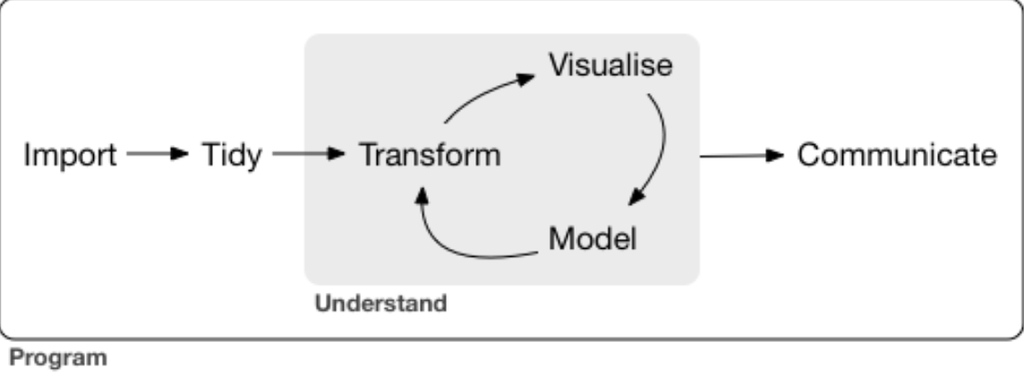

## Part III: Data Visualization with ggplot2

## ggplot2

- One of the most elegant and versatile systems for making graphs
- `ggplot` function from the `ggplot2` package,`ggplot2:ggplot()`

The `mpg` Data Frame

```r
> mpg
# A tibble: 234 x 11
   manufacturer model displ  year   cyl trans drv     cty   hwy fl    class
   <chr>        <chr> <dbl> <int> <int> <chr> <chr> <int> <int> <chr> <chr>
 1 audi         a4      1.8  1999     4 auto… f        18    29 p     comp…
 2 audi         a4      1.8  1999     4 manu… f        21    29 p     comp…
 3 audi         a4      2    2008     4 manu… f        20    31 p     comp…
 4 audi         a4      2    2008     4 auto… f        21    30 p     comp…
 5 audi         a4      2.8  1999     6 auto… f        16    26 p     comp…
 6 audi         a4      2.8  1999     6 manu… f        18    26 p     comp…
 7 audi         a4      3.1  2008     6 auto… f        18    27 p     comp…
 8 audi         a4 q…   1.8  1999     4 manu… 4        18    26 p     comp…
 9 audi         a4 q…   1.8  1999     4 auto… 4        16    25 p     comp…
10 audi         a4 q…   2    2008     4 manu… 4        20    28 p     comp…
# … with 224 more rows
```

## The diamonds Data Frame

```r
> diamonds
# A tibble: 53,940 x 10
   carat cut       color clarity depth table price     x     y     z
   <dbl> <ord>     <ord> <ord>   <dbl> <dbl> <int> <dbl> <dbl> <dbl>
 1 0.23  Ideal     E     SI2      61.5    55   326  3.95  3.98  2.43
 2 0.21  Premium   E     SI1      59.8    61   326  3.89  3.84  2.31
 3 0.23  Good      E     VS1      56.9    65   327  4.05  4.07  2.31
 4 0.290 Premium   I     VS2      62.4    58   334  4.2   4.23  2.63
 5 0.31  Good      J     SI2      63.3    58   335  4.34  4.35  2.75
 6 0.24  Very Good J     VVS2     62.8    57   336  3.94  3.96  2.48
 7 0.24  Very Good I     VVS1     62.3    57   336  3.95  3.98  2.47
 8 0.26  Very Good H     SI1      61.9    55   337  4.07  4.11  2.53
 9 0.22  Fair      E     VS2      65.1    61   337  3.87  3.78  2.49
10 0.23  Very Good H     VS1      59.4    61   338  4     4.05  2.39
# … with 53,930 more rows
```

## Creating a `ggplot` object

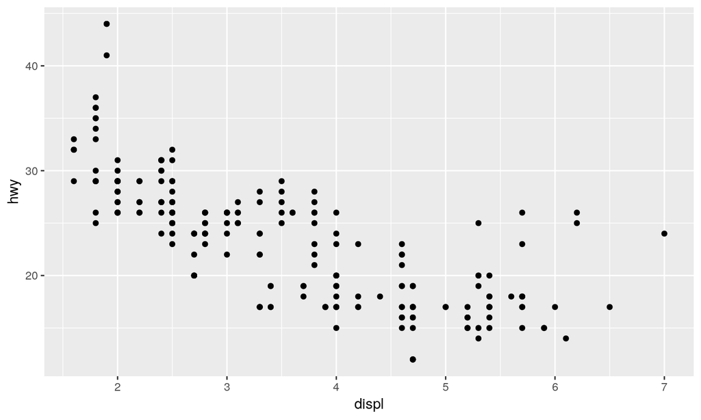

```r
> ggplot(data = mpg) +
+     geom_point(mapping = aes(x = displ, y = hwy))
```

```r
>
> #mpg %>%
>   #qplot(x = displ,y = wt, geom = "point")
```

## Equivalent forms

Here are other approaches to construct `ggplot` objects that creates the same plot.

```r
> ggplot(data = mpg) + geom_point(mapping = aes(x = displ, y = hwy))
```

```r
> ggplot(mpg) + geom_point(aes(displ, hwy))
```

```r
> mpg %>% ggplot(aes(displ, hwy)) + geom_point()
```

## A Graphing Template

```r
> ## ggplot(data = <DATA>) +
> ##     <GEOM_FUNCTION>(
> ##           mapping = aes(<MAPPINGS>),
> ##              stat = <STAT>,
> ##        position  = <POSITION>
> ##      )+
> ##      <COORDINATE_FUNCTION> +
> ##      <FACET_FUNCTION>
```

#### There are plenty of `geom_function`, `coordinate_function`, `facet_functions`, etc., in `ggplot`, I just listed some common functions.

## `geom_point()`

- `geom_point()`: plot the points
- Add a third variable to a two dimensional scatterplot by mapping it to an aesthetic

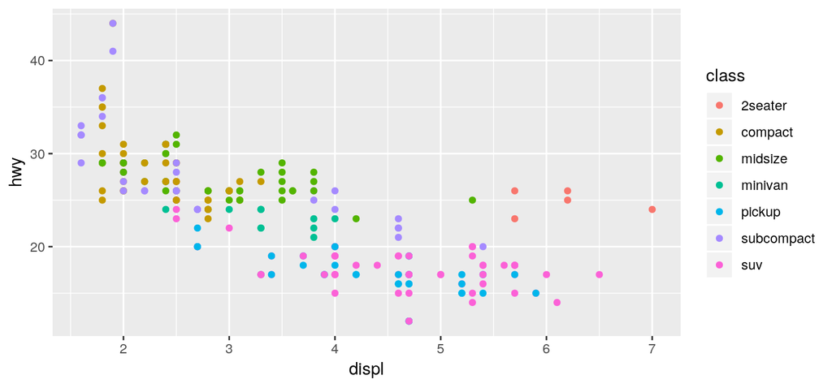

```r
> ggplot(data = mpg) + geom_point(mapping = aes(x = displ, y = hwy, color = class))
```

## `geom_smooth()`

- `geom_smooth()`: plot the smooth lines
- `show.lengend = FALSE`: no lengend
- `se = FALSE`: no se interval in the `plot(shadow)`

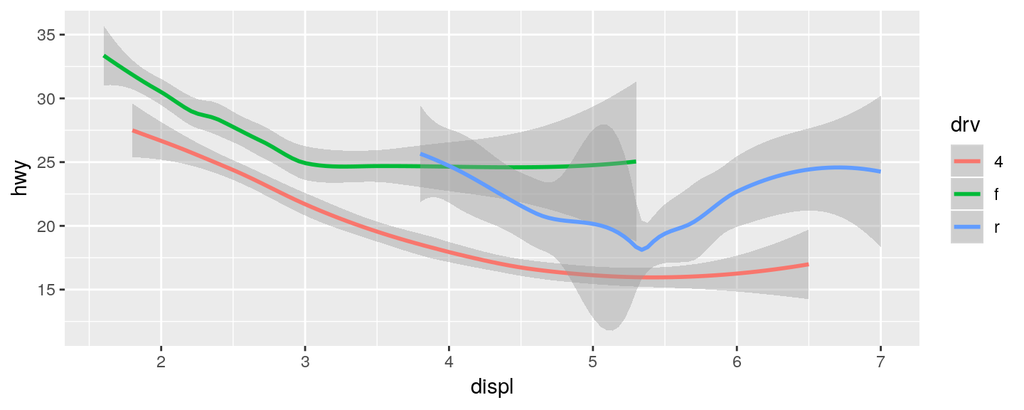

```r
> ggplot(data = mpg) + geom_smooth(mapping = aes(x = displ, y = hwy, color = drv))
`geom_smooth()` using method = 'loess' and formula 'y ~ x'
```

## `geom_bar()`

- Bar chart, default the `y` is the count, `like stat_count()`.
- Categorical variables are usually saved as factors or character vectors, examine the distribution of it, use a bar chart.
- For the barplot, the function removes the `NA` value.

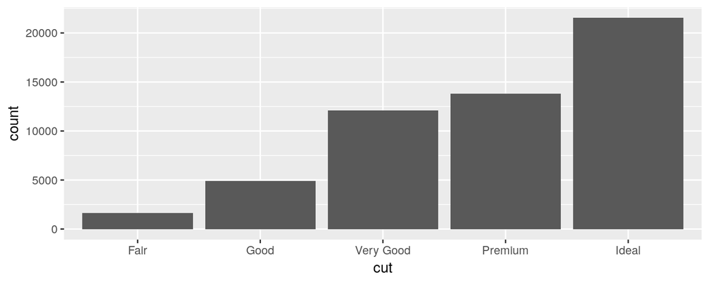

```r
> ggplot(diamonds) + geom_bar(mapping = aes(x = cut))
```

## `..prop..`

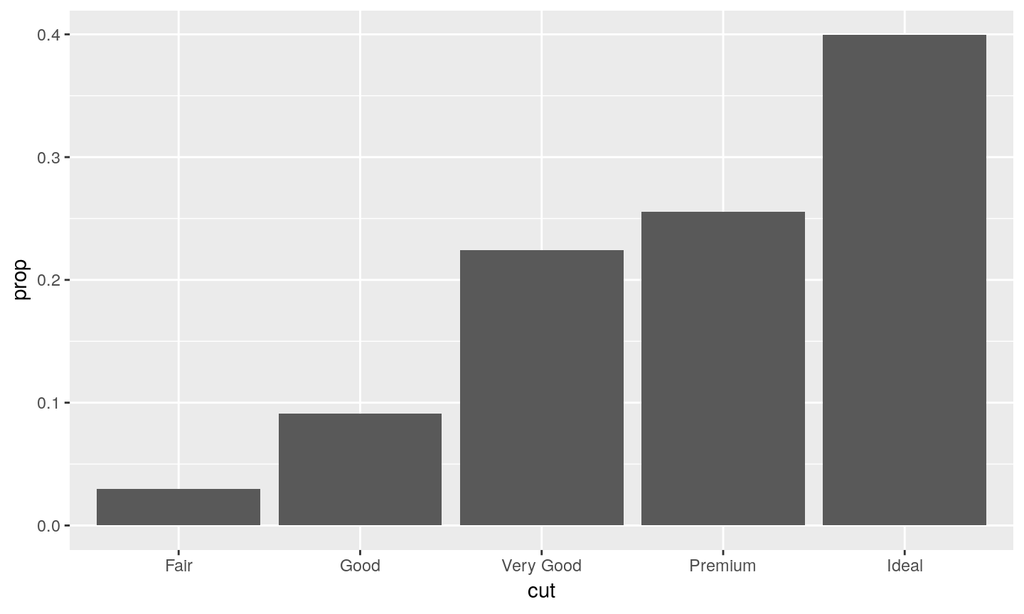

```r
> ggplot(diamonds) + geom_bar(mapping = aes(x = cut, y = ..prop.., group = 1))
```

## `geom_histogram()`

- histogram
- To examine the continuous variables distribution, we usually use the histogram

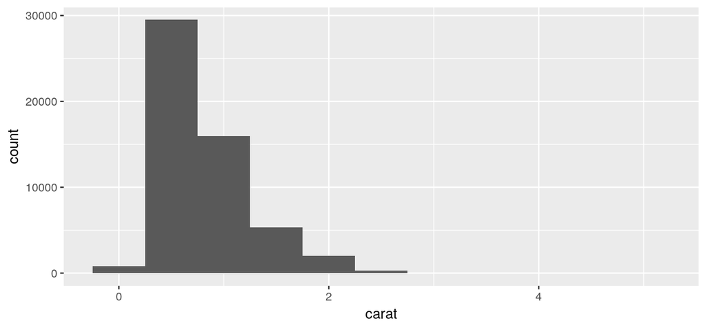

```r
> ggplot(diamonds, mapping = aes(carat)) + geom_histogram(binwidth = 0.5)
```

## `geom_freqpoly()`

- overlay multiple histograms in the same plot, `geom_freqpoly()` better than `geom_histogram()`.
- performs the same calculation as geom_histogram, but it saves as lines not bars.

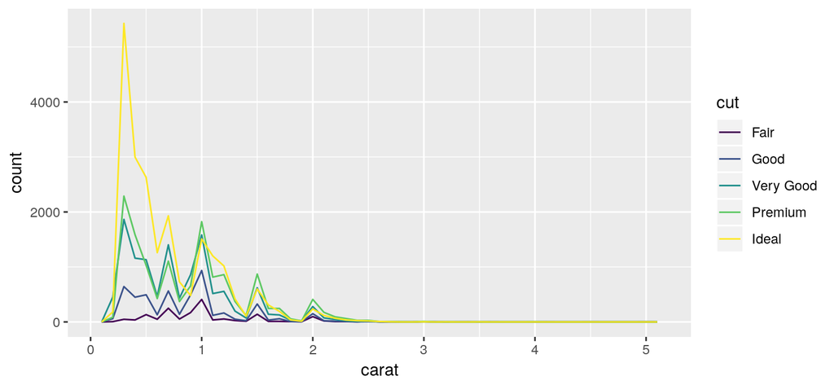

```r
> ggplot(diamonds, mapping = aes(carat, color = cut)) + geom_freqpoly(binwidth = 0.1)
```

## `geom_boxplot()`

Boxplot:

- A box stretches from the 25th percentile of the distribution to the 75th percentile(IQR)
- Middle of the box is a line that display the median(symmetric or skewed to one side)
- Visual points that display observations that fall more than 1.5 times the IQR from either edge of the box, the outlying points are unusual so plotted individually
- A line that extends from each end of the box and goes to the farthest nonoutlier point in the distribution

Display the distribution of a continuous variables broken down by a categorical one by boxplot

## `R`

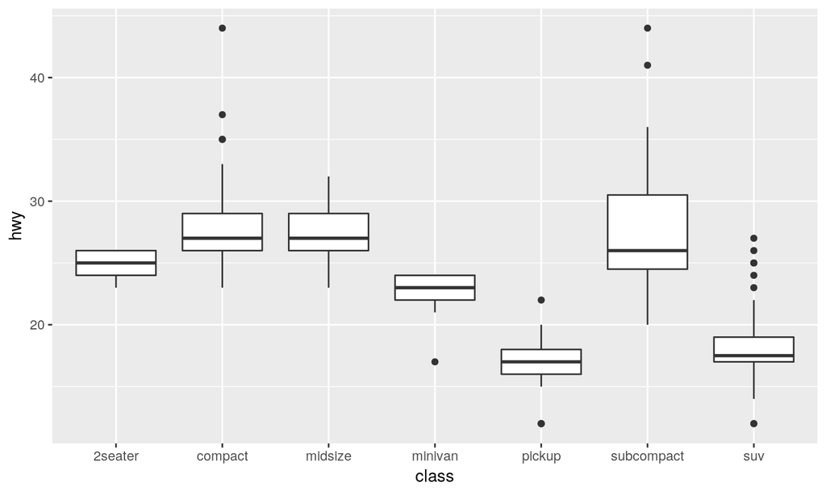

```r
> ggplot(mpg, aes(class, hwy)) + geom_boxplot()
```

## `geom_abline()`

- Draw a line with a slope and intercept as parameters

[figure not shown]

```r
> models <- tibble(a1 = runif(250, -20, 40), a2 = runif(250, -5, -5))
> ggplot(sim1, aes(x, y)) + geom_abline(aes(intercept = a1, slope = a2), data = models,
+     alpha = 1/4) + geom_point()
```

## `stat_count()`

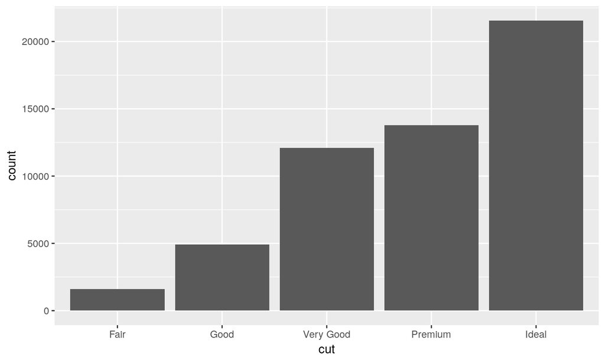

```r
> ggplot(diamonds) + stat_count(mapping = aes(x = cut))
```

## `stat_summary()`

- summarizes the `y` values for each unique `x` value

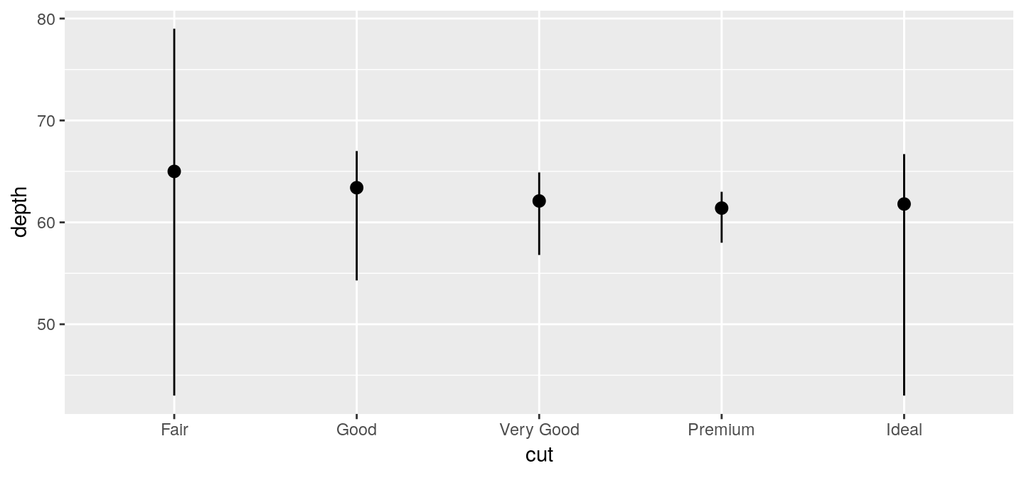

```r
> ggplot(diamonds) + stat_summary(mapping = aes(x = cut, y = depth), fun.ymin = min,
+     fun.ymax = max, fun.y = median)
```

## `geom_jitter()`

- avoid the points overlap each other
- makes our graph less accurate at small scales, but it makes graph more revealing at large scales

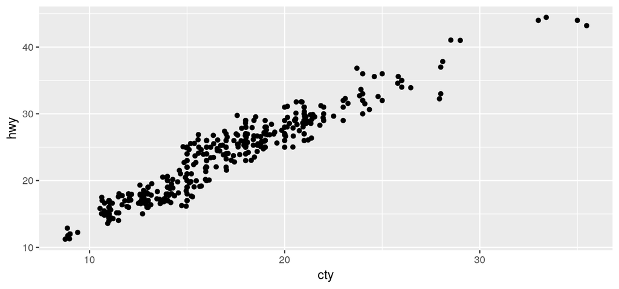

```r
> ggplot(mpg, mapping = aes(cty, hwy)) + geom_point() + geom_jitter(width = 0.5,
+     height = 1)
```

## `coord_flip()`

- switches the x-axes and y-axes
- `coord_quickmap()`: sets the aspect ratio correctly for maps
- `coord_polar()`: use polar coordinates

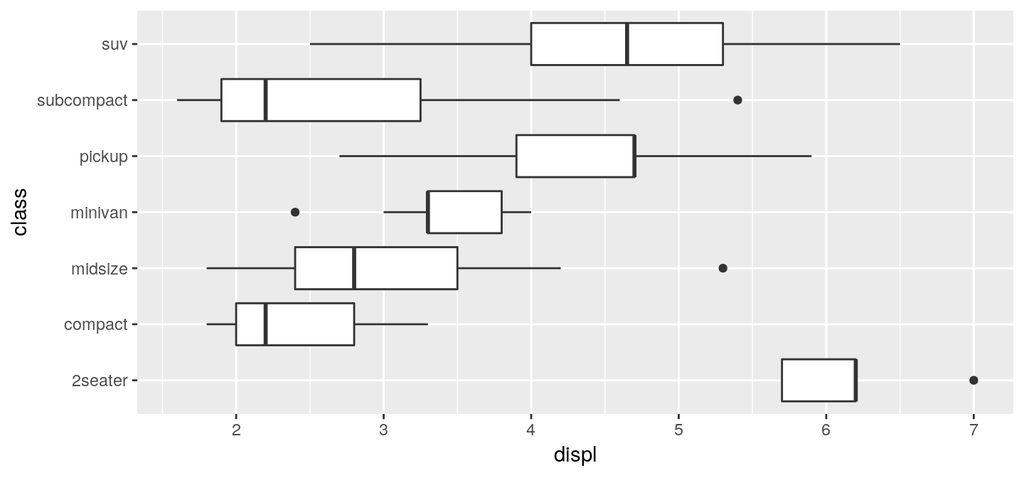

```r
> ggplot(mpg, mapping = aes(x = class, y = displ)) + geom_boxplot() + coord_flip()
```

## `facet_wrap()` & `facet_grid()`

- facet plot by a single variable(discrete)

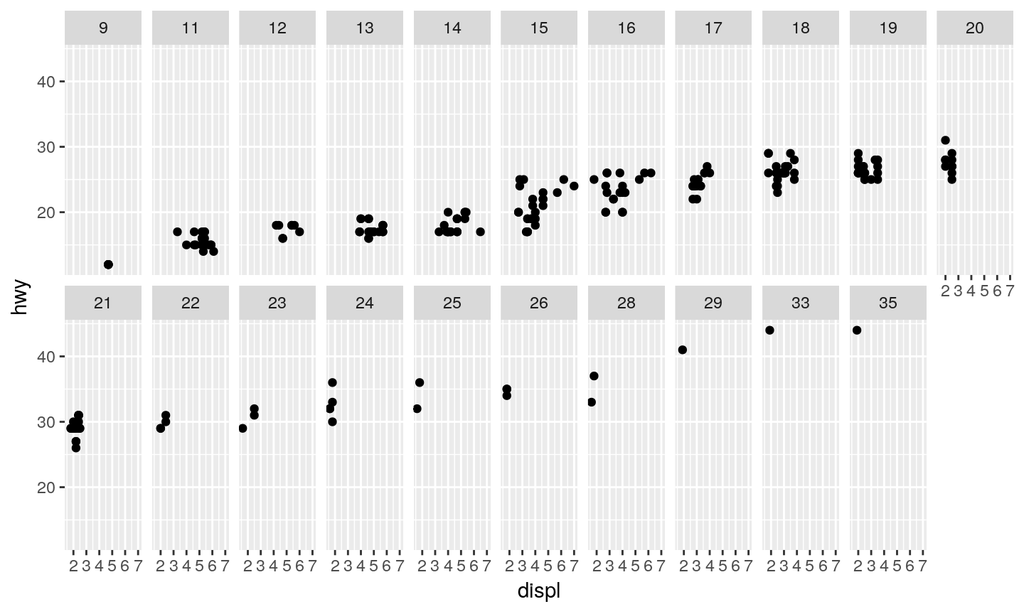

```r
> ggplot(mpg) + geom_point(mapping = aes(x = displ, y = hwy)) + facet_wrap(~cty,
+     nrow = 2)
```

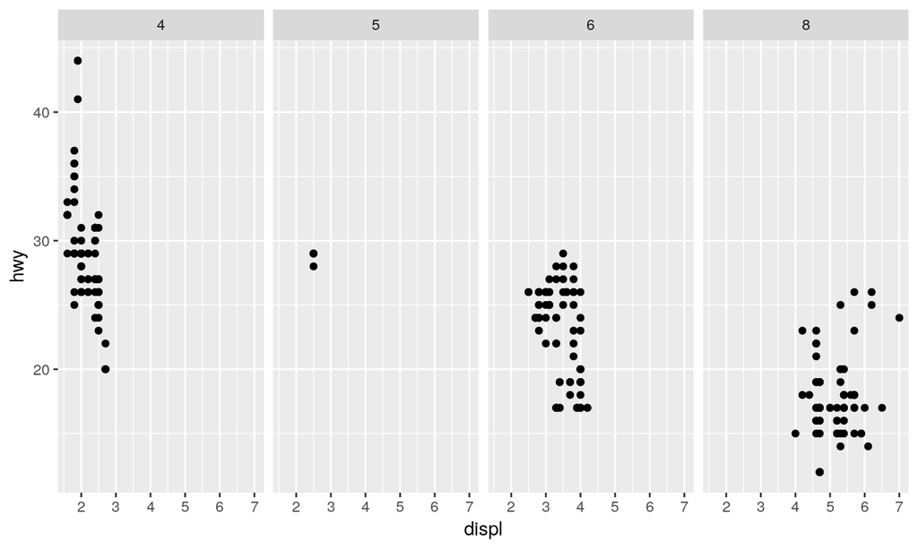

```r
> ggplot(mpg) + geom_point(mapping = aes(x = displ, y = hwy)) + facet_grid(. ~
+     cyl)
```

## Exercise 1

What has gone wrong with this code? Why are the points not blue?

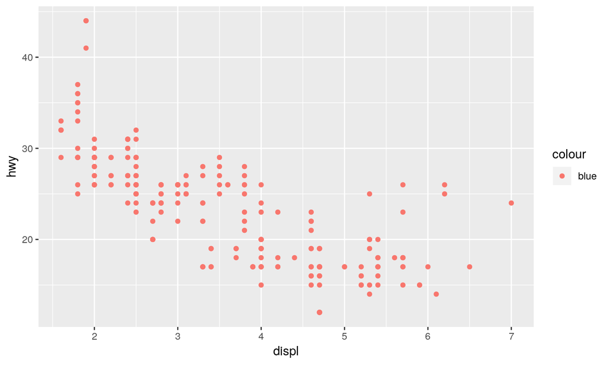

```r
> ggplot(mpg) + geom_point(mapping = aes(x = displ, y = hwy, color = "blue"))
```

## Exercise 2

Re-create the code necessary to generate the following graph

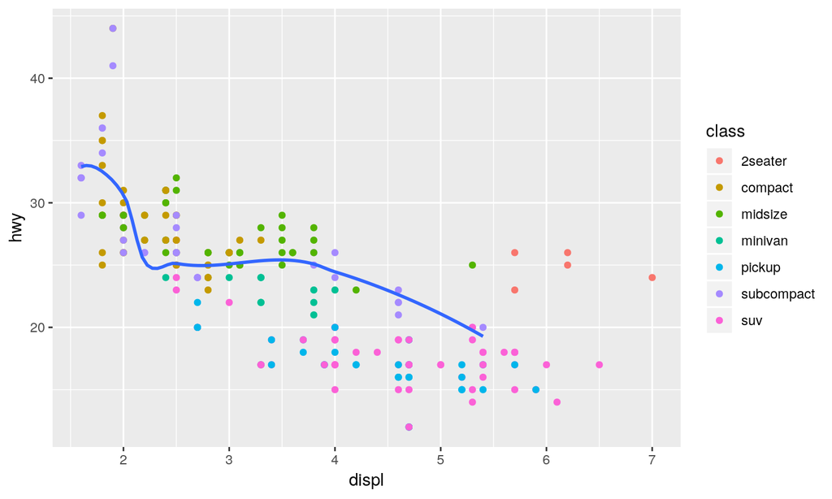

## Part IV: Graphs for Communication with `ggplot2`

## Label

- The easist place to start when turning an exploratory graphic into an expository graphic is with good labels
- Add labels with the `labs()` function

## `R`

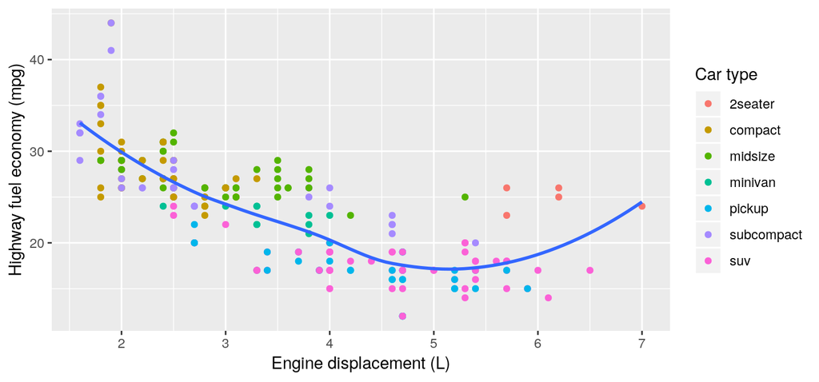

```r
> ggplot(mpg, aes(displ, hwy)) + geom_point(aes(color = class)) + geom_smooth(se = FALSE) +
+     labs(x = "Engine displacement (L)", y = "Highway fuel economy (mpg)", color = "Car type")
`geom_smooth()` using method = 'loess' and formula 'y ~ x'
```

## Template:

- `title()`: add titile as to summarize the main finding
- `subtitle()`: adds additional detail in a smaller font beneath the title
- `caption()`: adds text at the bottom right of the plot, often used to describe the source of the data

```r
> ##ggplot()+
> ##  geom_function()+
> ##  labs(
> ##  title = "",
> ##  subtitle = "",
> ##  caption = ""
> ##  )
```

## `R`

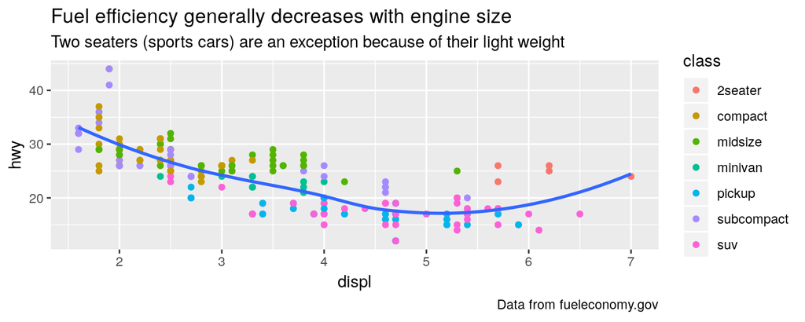

```r
> ggplot(mpg, aes(displ, hwy)) + geom_point(aes(color = class)) + geom_smooth(se = FALSE) +
+     labs(title = paste("Fuel efficiency generally decreases with", "engine size"),
+         subtitle = paste("Two seaters (sports cars) are an exception", "because of their light weight"),
+         caption = "Data from fueleconomy.gov")
`geom_smooth()` using method = 'loess' and formula 'y ~ x'
```

## `quote()`

- use mathematical equations instead of text strings

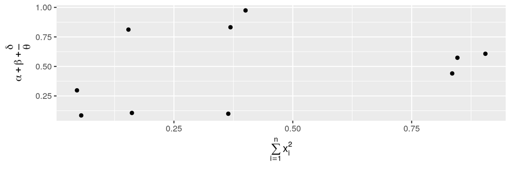

```r
> df <- tibble(x = runif(10), y = runif(10))
> ggplot(df, aes(x, y)) + geom_point() + labs(x = quote(sum(x[i]^2, i == 1, n)),
+     y = quote(alpha + beta + frac(delta, theta)))
```

## `geom_label()`

- Draw a rectangle behind the text, use the `nudge_y` parameter to move the labels slightly above the corresponding points
- `ggrepel::geom_label_repel()` automatically adjusts labels
- Prepare to highlight the "best in class"

```r
> best_in_class <- mpg %>%
+   group_by(class) %>%
+   filter(row_number(desc(hwy)) == 1)
```

## `geom_label()`

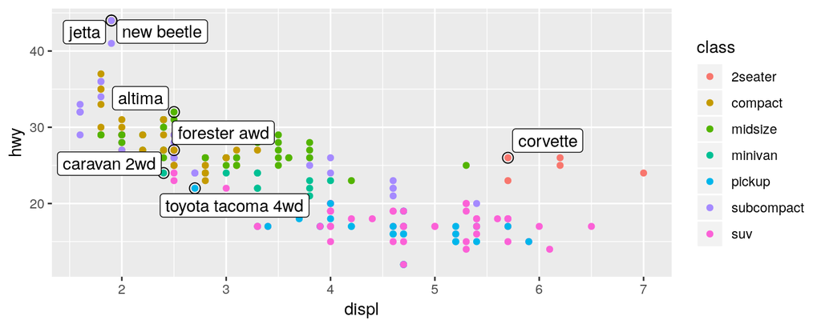

```r
> ggplot(mpg, aes(displ, hwy)) + geom_point(aes(color = class)) + geom_point(size = 3,
+     shape = 1, data = best_in_class) + ggrepel::geom_label_repel(aes(label = model),
+     data = best_in_class)
```

## Axis Ticks

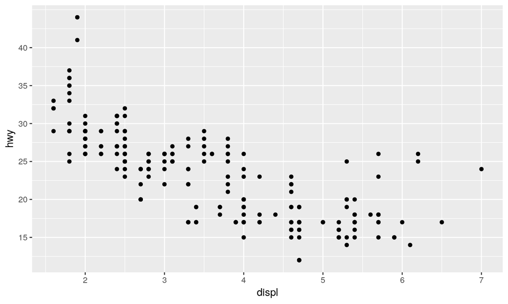

```r
> ggplot(mpg, aes(displ, hwy)) + geom_point() + scale_y_continuous(breaks = seq(15,
+     40, by = 5))
```

## `R`

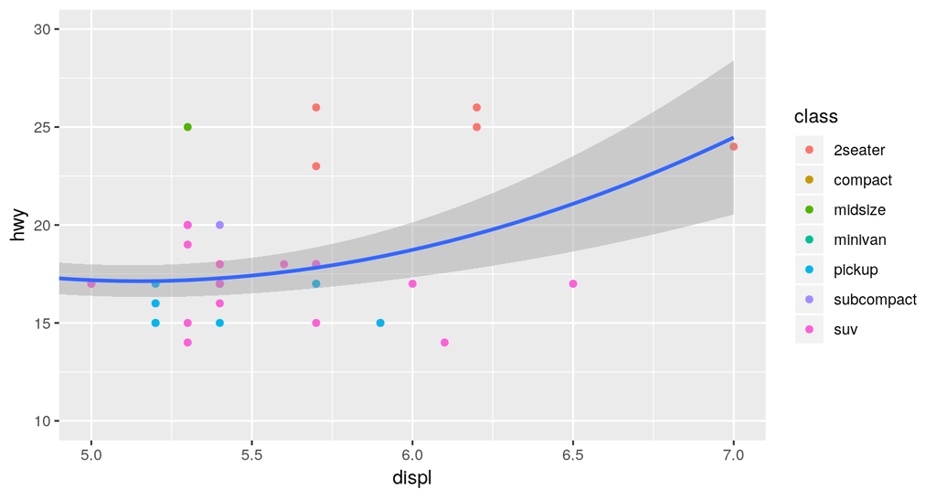

```r
> ggplot(mpg, aes(displ, hwy)) + geom_point(aes(color = class)) + geom_smooth() +
+     coord_cartesian(xlim = c(5, 7), ylim = c(10, 30))
`geom_smooth()` using method = 'loess' and formula 'y ~ x'
```

## Part V: Brainstorm

## "-" in `R`

- matrics: `-n` means select all rows or columns except the nth, same as `FALSE`.

```r
> (df <- tibble(x = 1:3, y = 3:1, z = letters[1:3]))
# A tibble: 3 x 3
      x     y z
  <int> <int> <chr>
1     1     3 a
2     2     2 b
3     3     1 c
> df[, -2]
# A tibble: 3 x 2
      x z
  <int> <chr>
1     1 a
2     2 b
3     3 c
> df[, c(TRUE, TRUE, FALSE)]
# A tibble: 3 x 2
      x     y
  <int> <int>
1     1     3
2     2     2
3     3     1
```

## "-" in `R`

```r
> remove_last <- function(x) {
+     if (length(x) <= 1)
+         return(NULL)
+     x[-length(x)]
+ }
> remove_last(c(1, 2, 3))
[1] 1 2
```

## "-" in `R`

```r
> df <- tribble(~y, ~x1, ~x2, 4, 2, 5, 5, 1, 6)
> model_matrix(df, y ~ x1)
# A tibble: 2 x 2
  `(Intercept)`    x1
          <dbl> <dbl>
1             1     2
2             1     1
> # drop the intercept to the model
> model_matrix(df, y ~ x1 - 1)
# A tibble: 2 x 1
     x1
  <dbl>
1     2
2     1
```

## `R`

- `arrange()`: `-` means descending order.

```r
> library(nycflights13)
> arrange(flights, year, month, day)
# A tibble: 336,776 x 19
    year month   day dep_time sched_dep_time dep_delay arr_time
   <int> <int> <int>    <int>          <int>     <dbl>    <int>
 1  2013     1     1      517            515         2      830
 2  2013     1     1      533            529         4      850
 3  2013     1     1      542            540         2      923
 4  2013     1     1      544            545        -1     1004
 5  2013     1     1      554            600        -6      812
 6  2013     1     1      554            558        -4      740
 7  2013     1     1      555            600        -5      913
 8  2013     1     1      557            600        -3      709
 9  2013     1     1      557            600        -3      838
10  2013     1     1      558            600        -2      753
# … with 336,766 more rows, and 12 more variables: sched_arr_time <int>,
#   arr_delay <dbl>, carrier <chr>, flight <int>, tailnum <chr>,
#   origin <chr>, dest <chr>, air_time <dbl>, distance <dbl>, hour <dbl>,
#   minute <dbl>, time_hour <dttm>
> q1 <- arrange(flights, desc(arr_delay))
> q2 <- arrange(flights, -arr_delay)
> identical(q1, q2)
[1] TRUE
```

## `R`

- `gather()`: `-` means gather all columns expect that one

```r
> table4a
# A tibble: 3 x 3
  country     `1999` `2000`
* <chr>        <int>  <int>
1 Afghanistan    745   2666
2 Brazil       37737  80488
3 China       212258 213766
> table4a %>% gather(year, cases, -country)
# A tibble: 6 x 3
  country     year   cases
  <chr>       <chr>  <int>
1 Afghanistan 1999     745
2 Brazil      1999   37737
3 China       1999  212258
4 Afghanistan 2000    2666
5 Brazil      2000   80488
6 China       2000  213766
```